# Issue #4 - Traversal of the space of cross-validation folds

## Content

- Objective
- Methodolgy
- Exploratory Data Analysis
- Observations
- Conclusions

Evaluating a Machine Learning model can be quite tricky. Usually, we split the data set into training and testing sets and use the training set to train the model and testing set to test the model. We then evaluate the model performance based on an error metric to determine the accuracy of the model. This method however, is not very reliable as the accuracy obtained for one test set can be very different to the accuracy obtained for a different test set _(as shown [here](https://github.com/elie-wanko/PRESC/blob/Issue%233-Traversal_of_the_space_of_traintest_splits/dev/elie_wanko/Issue%20%233%20-%20Traversal%20of%20the%20space%20of%20train_test%20splits.ipynb))_. K-fold Cross Validation(CV) provides a solution to this problem by dividing the data into folds and ensuring that each fold is used as a testing set at some point.

### Objective

Similarly to Issue #3, we want to investigate how much the performance score computed using cross-validation depends on the number of folds. Eg. how would our performance estimate change if we used 10-fold rather than 5-fold?

### Methodolgy

Write a function that takes a scikit-learn estimator([Logistic Regression](http://scikit-learn.org/stable/modules/generated/sklearn.linear_model.LogisticRegression.html)) and a [dataset](https://github.com/elie-wanko/PRESC/blob/master/datasets/defaults.csv), then compute an evaluation metric using repeated [K-fold cross-validation](https://scikit-learn.org/stable/modules/generated/sklearn.model_selection.KFold.html) over a grid of K values from 1 to n. It should output a table of K with the average metric value across the folds, one for each repeat. A prepliminary analysis of our data set (defaults.csv) can be referenced [here](https://github.com/elie-wanko/PRESC/blob/Issue%232-Train_and_test_a_classification_model/dev/elie_wanko/Issue%20%232%20-%20Train%20and%20test%20a%20classification%20model.ipynb)

### EDA

#### Importing Libraries

```python
# Basic Computations
import statistics as stats
import numpy as np
import pandas as pd
import seaborn as sns
import matplotlib.pyplot as plt
%matplotlib inline
%config InlineBackend.figure_format='retina'

# Dynamic Markdowns
from IPython.display import Markdown as md
# Clear Warnings
import warnings; warnings.simplefilter('ignore')
```

```python
#**Adding module’s sub-directory to Pythons path**
import os
import sys
sys.path.insert(0, os.path.abspath('../elie_wanko/modules'))
import helpers, summary
```

#### Data Pre-Processing

```python
df_data = pd.read_csv("defaults_data.csv")
df_data
```

|  | limit_bal | sex | education | marriage | age | pay_1 | pay_2 | pay_3 | pay_4 | pay_5 | ... | bill_amt4 | bill_amt5 | bill_amt6 | pay_amt1 | pay_amt2 | pay_amt3 | pay_amt4 | pay_amt5 | pay_amt6 | defaulted |
| --- | --- | --- | --- | --- | --- | --- | --- | --- | --- | --- | --- | --- | --- | --- | --- | --- | --- | --- | --- | --- | --- |
| 0 | 20000 | 2 | 2 | 1 | 24 | 2 | 2 | -1 | -1 | -2 | ... | 0 | 0 | 0 | 0 | 689 | 0 | 0 | 0 | 0 | 1 |
| 1 | 120000 | 2 | 2 | 2 | 26 | -1 | 2 | 0 | 0 | 0 | ... | 3272 | 3455 | 3261 | 0 | 1000 | 1000 | 1000 | 0 | 2000 | 1 |
| 2 | 90000 | 2 | 2 | 2 | 34 | 0 | 0 | 0 | 0 | 0 | ... | 14331 | 14948 | 15549 | 1518 | 1500 | 1000 | 1000 | 1000 | 5000 | 0 |
| 3 | 50000 | 2 | 2 | 1 | 37 | 0 | 0 | 0 | 0 | 0 | ... | 28314 | 28959 | 29547 | 2000 | 2019 | 1200 | 1100 | 1069 | 1000 | 0 |
| 4 | 50000 | 1 | 2 | 1 | 57 | -1 | 0 | -1 | 0 | 0 | ... | 20940 | 19146 | 19131 | 2000 | 36681 | 10000 | 9000 | 689 | 679 | 0 |
| ... | ... | ... | ... | ... | ... | ... | ... | ... | ... | ... | ... | ... | ... | ... | ... | ... | ... | ... | ... | ... | ... |
| 29995 | 220000 | 1 | 3 | 1 | 39 | 0 | 0 | 0 | 0 | 0 | ... | 88004 | 31237 | 15980 | 8500 | 20000 | 5003 | 3047 | 5000 | 1000 | 0 |
| 29996 | 150000 | 1 | 3 | 2 | 43 | -1 | -1 | -1 | -1 | 0 | ... | 8979 | 5190 | 0 | 1837 | 3526 | 8998 | 129 | 0 | 0 | 0 |
| 29997 | 30000 | 1 | 2 | 2 | 37 | 4 | 3 | 2 | -1 | 0 | ... | 20878 | 20582 | 19357 | 0 | 0 | 22000 | 4200 | 2000 | 3100 | 1 |
| 29998 | 80000 | 1 | 3 | 1 | 41 | 1 | -1 | 0 | 0 | 0 | ... | 52774 | 11855 | 48944 | 85900 | 3409 | 1178 | 1926 | 52964 | 1804 | 1 |
| 29999 | 50000 | 1 | 2 | 1 | 46 | 0 | 0 | 0 | 0 | 0 | ... | 36535 | 32428 | 15313 | 2078 | 1800 | 1430 | 1000 | 1000 | 1000 | 1 |

30000 rows × 24 columns

#### Analysis

In our analysis, we are considering the following folds shown in the table below.

```python
kf_splits = np.arange(2, 21)
print("\033[1m" + 'K-Folds : ' + str(set(kf_splits)) + "\033[0m")
```

```
K-Folds : {2, 3, 4, 5, 6, 7, 8, 9, 10, 11, 12, 13, 14, 15, 16, 17, 18, 19, 20}
```

#### Results

```python
knn_cv_scores_summary = summary.cv_folds(data=df_data, sizes=kf_splits, model='knn')
knn_cv_scores_summary.style.apply(
    helpers.highlight_max, subset=['Accuracy Score', 'Precision Score', 'Recall Score', 'F1 Score'], color='#71a5bd').apply(
    helpers.highlight_min, subset=['Log Loss', 'Av. Processing Time(sec.)'], color='#71a5bd').hide_index()
```

| K Folds | Accuracy Score | Precision Score | Recall Score | F1 Score | Log Loss | Av. Processing Time(sec.) |
| --- | --- | --- | --- | --- | --- | --- |
| 2 | 0.759367 | 0.389064 | 0.152954 | 0.219297 | 1.550837 | 21.016589 |
| 3 | 0.760233 | 0.394922 | 0.157926 | 0.225068 | 1.612407 | 20.439978 |
| 4 | 0.761167 | 0.399373 | 0.157173 | 0.225171 | 1.588799 | 23.395097 |
| 5 | 0.761634 | 0.400515 | 0.154612 | 0.222698 | 1.612771 | 23.589210 |
| 6 | 0.762267 | 0.403831 | 0.155817 | 0.224374 | 1.584665 | 31.688907 |
| 7 | 0.761900 | 0.402481 | 0.158228 | 0.226487 | 1.612153 | 25.234017 |
| 8 | 0.763168 | 0.408144 | 0.155369 | 0.224442 | 1.611702 | 26.691488 |
| 9 | 0.764234 | 0.413965 | 0.159738 | 0.230021 | 1.598149 | 29.095752 |
| 10 | 0.763701 | 0.410783 | 0.158373 | 0.227935 | 1.616671 | 25.746332 |
| 11 | 0.763700 | 0.409489 | 0.157176 | 0.226550 | 1.610025 | 28.913199 |
| 12 | 0.764000 | 0.412177 | 0.158981 | 0.228827 | 1.620982 | 31.044983 |
| 13 | 0.763568 | 0.409259 | 0.157334 | 0.226714 | 1.612803 | 30.720990 |
| 14 | 0.763733 | 0.409516 | 0.156118 | 0.225207 | 1.639637 | 32.308004 |
| 15 | 0.764435 | 0.413840 | 0.158391 | 0.228184 | 1.622752 | 33.985928 |
| 16 | 0.763868 | 0.411118 | 0.155957 | 0.225395 | 1.608942 | 33.555870 |
| 17 | 0.764468 | 0.414826 | 0.160650 | 0.230819 | 1.627356 | 35.292327 |
| 18 | 0.764300 | 0.414774 | 0.159875 | 0.230032 | 1.629305 | 32.382492 |
| 19 | 0.764035 | 0.412851 | 0.159290 | 0.228769 | 1.632355 | 28.784914 |
| 20 | 0.763901 | 0.411493 | 0.159124 | 0.228685 | 1.639531 | 47.219727 |

```python
logreg_cv_scores_summary = summary.cv_folds(data=df_data, sizes=kf_splits, model='logreg')
logreg_cv_scores_summary.style.apply(
    helpers.highlight_max, subset=['Accuracy Score', 'Precision Score', 'Recall Score', 'F1 Score'], color='#71bd7e').apply(
    helpers.highlight_min, subset=['Log Loss', 'Av. Processing Time(sec.)'], color='#71bd7e').hide_index()
```

| K Folds | Accuracy Score | Precision Score | Recall Score | F1 Score | Log Loss | Av. Processing Time(sec.) |
| --- | --- | --- | --- | --- | --- | --- |
| 2 | 0.806667 | 0.692441 | 0.237342 | 0.350681 | 0.469244 | 13.152596 |
| 3 | 0.799567 | 0.698867 | 0.174503 | 0.274722 | 0.471648 | 21.050960 |
| 4 | 0.807200 | 0.698612 | 0.229204 | 0.343328 | 0.469636 | 34.224816 |
| 5 | 0.801867 | 0.693423 | 0.194699 | 0.300490 | 0.473650 | 43.595392 |
| 6 | 0.805700 | 0.689211 | 0.224684 | 0.336736 | 0.473351 | 70.885431 |
| 7 | 0.803267 | 0.699384 | 0.195298 | 0.303344 | 0.473268 | 99.448808 |
| 8 | 0.803968 | 0.693510 | 0.209315 | 0.318750 | 0.473206 | 114.285110 |
| 9 | 0.802934 | 0.695290 | 0.194392 | 0.302564 | 0.472830 | 233.766449 |
| 10 | 0.803435 | 0.697570 | 0.198916 | 0.306637 | 0.475151 | 105.246389 |
| 11 | 0.798534 | 0.684525 | 0.171958 | 0.264087 | 0.477960 | 115.283390 |
| 12 | 0.801600 | 0.687732 | 0.195148 | 0.301021 | 0.474528 | 131.978783 |
| 13 | 0.804002 | 0.699397 | 0.203448 | 0.313061 | 0.471868 | 135.995606 |
| 14 | 0.805167 | 0.688691 | 0.219861 | 0.331473 | 0.472113 | 153.674445 |
| 15 | 0.801769 | 0.692951 | 0.182191 | 0.284902 | 0.475178 | 173.951487 |
| 16 | 0.796268 | 0.686056 | 0.156578 | 0.248226 | 0.479968 | 162.471020 |
| 17 | 0.803335 | 0.689366 | 0.208420 | 0.316686 | 0.475388 | 176.751994 |
| 18 | 0.801767 | 0.695466 | 0.182329 | 0.283783 | 0.474761 | 199.398061 |
| 19 | 0.801735 | 0.697459 | 0.191082 | 0.294563 | 0.474360 | 198.394381 |
| 20 | 0.797601 | 0.700153 | 0.156562 | 0.248316 | 0.476681 | 220.580285 |

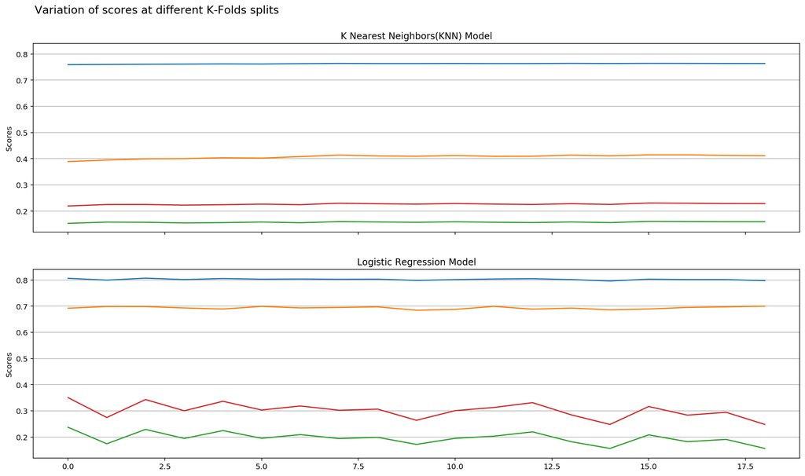

```python
fig, (ax1, ax2) = plt.subplots(2, sharex=True, sharey=True)
fig.set_figwidth(18)
fig.set_figheight(10)
fig.suptitle(t="Variation of scores at different K-Folds splits", x=0.25,  y=0.95, size='x-large')

ax1.set_title("K Nearest Neighbors(KNN) Model")
ax1.plot(knn_cv_scores_summary.filter(knn_cv_scores_summary.columns[1:-2]))
ax1.set_ylabel("Scores")
ax1.grid(axis='y')

ax2.set_title("Logistic Regression Model")
ax2.plot(logreg_cv_scores_summary.filter(logreg_cv_scores_summary.columns[1:-2]))
ax2.set_ylabel('Scores')
ax2.grid(axis='y')

plt.show()
```

#### Logistic Loss/Cross-entropy Loss at different K-Folds splits

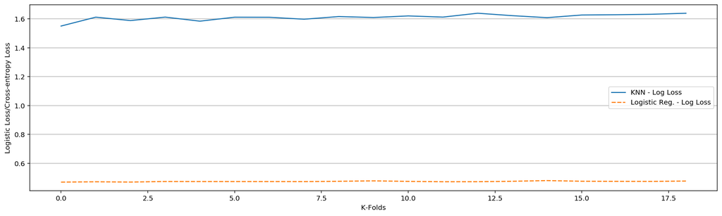

```python
log_losses = pd.concat([knn_cv_scores_summary.filter(knn_cv_scores_summary.columns[-2:-1]),
                             logreg_cv_scores_summary.filter(logreg_cv_scores_summary.columns[-2:-1])], axis=1)
log_losses.columns=['KNN - Log Loss', 'Logistic Reg. - Log Loss']

helpers.trend_plot(data=log_losses, xlabel = "K-Folds", ylabel = "Logistic Loss/Cross-entropy Loss")
```

#### Processing time at different K-Folds splits

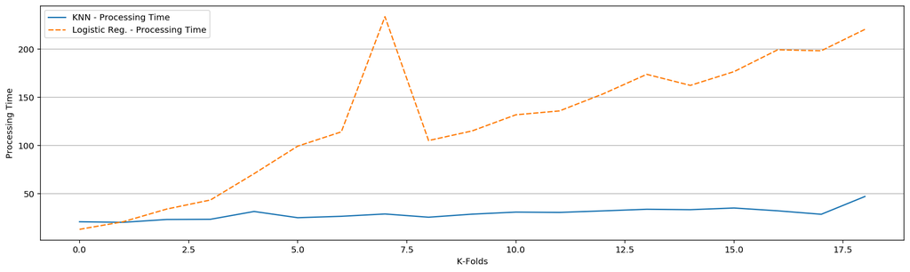

```python
processing_times = pd.concat([knn_cv_scores_summary.filter(knn_cv_scores_summary.columns[-1:]),
                             logreg_cv_scores_summary.filter(logreg_cv_scores_summary.columns[-1:])], axis=1)
processing_times.columns=['KNN - Processing Time', 'Logistic Reg. - Processing Time']

helpers.trend_plot(data=processing_times, xlabel="K-Folds", ylabel="Processing Time")
```

### Observations

From our results, it seems the variation in kfolds has no effects on improving the scores of our models. Most probably because it was unable to converge. To improve this, we could consider increase the number of iterations and use some post-processing to save the model when our performance scores reach a maximum and don't decrease after a x-terations.

We can observe that our log loss remain constant for both models despite the proportional increase in processing time with the k-folds for the Log Reg. models.